# Untitled

Juan Carlos Villaseñor-Derbez

last update 2018-04-10

# Test 2

The previous data exploration was a mess, and I need to re-start wrangling the data to have a dataset where I can actually ask many different questions.

Some of the questions are:

- Are `fishing hours` (from GFW) a better proxy of fishing effort than of `fishing days` (from Chilean data)?
- Can these (along with many boatl-level) be used to predict catches?
- How can we assign catches (reported on land) to individual points on the map?

## Load data

### Chile landings data

```r
chile_catches <- read.csv(here::here("raw_data","chile_landings_with_GFW.csv"), stringsAsFactors = F, na.strings = "null") %>%
  clean_names() %>%
  filter(matched,
         species == "ANCHOVETA",
         fishing_gear == "CERCO") %>%
  mutate(port_name = taxize_capwords(port_name, strict = T, onlyfirst = T),
         species = taxize_capwords(species, strict = T, onlyfirst = T),
         fishing_gear = taxize_capwords(fishing_gear, strict = T, onlyfirst = T),
         v_name = taxize_capwords(v_name, strict = T, onlyfirst = T),
         departure = lubridate::month(departure),
         arrival = lubridate::month(arrival),
         distance_traveled = as.numeric(distance_traveled),
         max_distance_from_shore = as.numeric(max_distance_from_shore),
         power = as.numeric(power),
         aux_power = as.numeric(aux_power)) %>%
  group_by(trip_id, year, departure, arrival, length, capacity, power, aux_power, trip_days, distance_traveled, max_distance_from_shore) %>%
  summarize(landings = sum(ton, na.rm = T)) %>%
  ungroup() %>%
  filter(landings > 1)
```

### GFW data

We want to add to this data some information from GFW. This dataset contains fishing hours for each position estimated from VMS data, as well as an indication on wheather the boat was fishing or not.

```r
gfw_data <- readRDS(here::here("raw_data","chilean_fleet_w_gfw.rds"))
```

```r
trip_info <- gfw_data %>%
  filter(nnet_score == 1,
         between(lon, -90, -65),
         between(lat, -60, 10)) %>%
  group_by(mmsi, trip_id) %>%
  summarize(min_lat = min(lat),
            max_lat = max(lat),
            mean_lat = mean(lat),
            median_lat = median(lat),
            mode_lat = get_mode(lat),
            min_lon = min(lon),
            max_lon = max(lon),
            mean_lon = mean(lon),
            median_lon = median(lon),
            mode_lon = get_mode(lon),
            hours = sum(hours)) %>%
  ungroup() %>%
  select(trip_id, mmsi, everything())

chile_catches_full <- chile_catches %>%
  left_join(trip_info, by = "trip_id") %>%
  filter(!is.na(mmsi))
```

```r
set.seed(43)
chile_split <- rsample::initial_split(chile_catches_full, prop = 0.8, strata = "year")

chile_train <- rsample::training(chile_split)

chile_test  <- rsample::testing(chile_split)
```

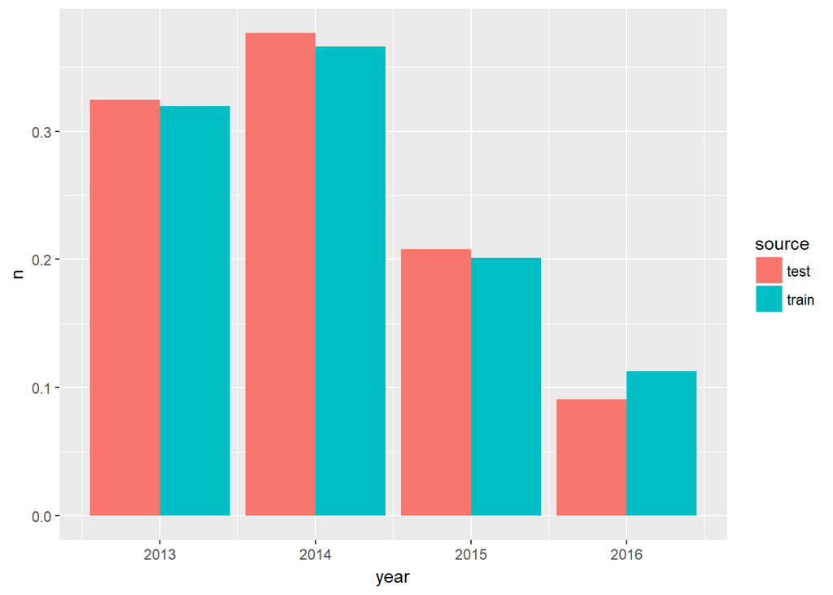

```r
chile_train %>%
  mutate(source = "train") %>%
  rbind(chile_test %>% mutate(source = "test")) %>%
  group_by(year, source) %>%
  count() %>%
  group_by(source) %>%
  mutate(n = n/sum(n)) %>%
  ungroup() %>%
  ggplot(aes(x = year, y = n, fill = source)) +
  geom_col(position = "dodge")
```

```r
chile_vfold <- rsample::vfold_cv(chile_train, v = 5, repeats = 1, strata = "year")
```

```r
lm_foo <- function(dep_var, ind_vars, split) {

  formula <- as.formula(paste0(dep_var, "~", paste(ind_vars, collapse = "+")))

  fitted_lm <- lm(formula, data = rsample::analysis(split))

  lm_performance <- rsample::assessment(split) %>%
    modelr::add_predictions(model = fitted_lm)

  lm_rq <- yardstick::rsq(lm_performance, truth = landings, estimate = pred)
}
```

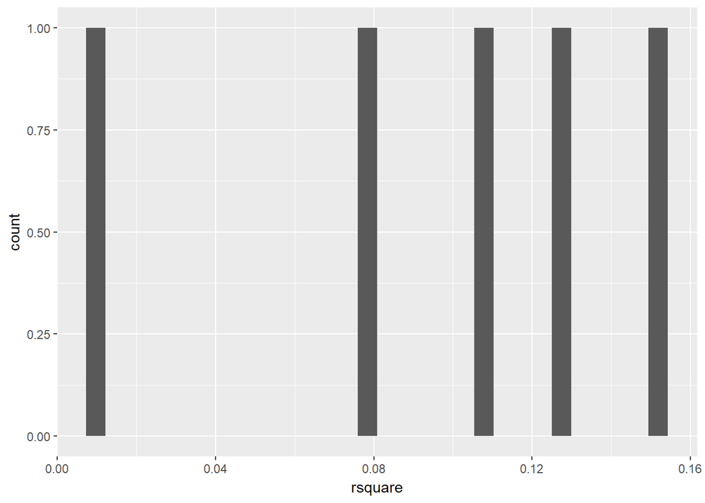

```r
dep_var <- "landings"
ind_vars <- c(".")

chile_vfold %>%
  mutate(rsquare = map_dbl(splits, lm_foo, dep_var = dep_var, ind_vars = ind_vars)) %>%
  ggplot(aes(rsquare)) +
  geom_histogram()
```

```r
candidate_variables <- chile_catches_full %>%
  select(-c(landings, mmsi, trip_id, departure, arrival, year)) %>%
  colnames()

third_rule <- round(length(candidate_variables) / 3)

candidate_params <-expand.grid(mtry = c(2, third_rule, length(candidate_variables)),
                               splitrule = c("variance", "extratrees", "maxstat")) %>%
  as_data_frame()

candidate_params
```

```
## # A tibble: 9 x 2
##    mtry splitrule
##   <dbl> <fct>
## 1  2.00 variance
## 2  6.00 variance
## 3 18.0  variance
## 4  2.00 extratrees
## 5  6.00 extratrees
## 6 18.0  extratrees
## 7  2.00 maxstat
## 8  6.00 maxstat
## 9 18.0  maxstat
```

```r
chile_recipe <- chile_catches_full %>%
  select(dep_var, candidate_variables) %>%
  recipes::recipe(landings ~ ., data = .) %>%
  recipes::step_log(all_outcomes()) %>%
  recipes::step_center(all_predictors()) %>%
  recipes::step_scale(all_predictors()) %>%
  recipes::step_meanimpute(all_predictors())

chile_recipe
```

```
## Data Recipe
##
## Inputs:
##
##       role #variables
##    outcome          1
##  predictor         18
##
## Operations:
##
## Log transformation on all_outcomes()
## Centering for all_predictors()
## Scaling for all_predictors()
## Mean Imputation for all_predictors()
```

```r
chile_prepped <- recipes::prep(chile_recipe, training = chile_catches_full)

chile_prepped
```

```
## Data Recipe
##
## Inputs:
##
##       role #variables
##    outcome          1
##  predictor         18
##
## Training data contained 1936 data points and no missing data.
##
## Operations:
##
## Log transformation on landings [trained]
## Centering for length, capacity, power, ... [trained]
## Scaling for length, capacity, power, ... [trained]
## Mean Imputation for length, capacity, power, ... [trained]
```

```r
chile_baked <- recipes::bake(chile_prepped, newdata = chile_catches_full)

head(chile_baked)
```

```
## # A tibble: 6 x 19
##   length capacity  power aux_power trip_days distance_traveled
##    <dbl>    <dbl>  <dbl>     <dbl>     <dbl>             <dbl>
## 1 -0.479   -0.251 -0.475    -0.832   -0.0349           -0.0799
## 2 -0.479   -0.251 -0.475    -0.832   -0.0349           -0.0926
## 3 -0.479   -0.251 -0.475    -0.832   -0.0349           -0.0723
## 4 -0.479   -0.251 -0.475    -0.832   -0.0349           -0.0559
## 5 -0.479   -0.251 -0.475    -0.832   -0.0109            0.116
## 6 -0.479   -0.251 -0.475    -0.832    0.0372           -0.0324
## # ... with 13 more variables: max_distance_from_shore <dbl>,
## #   landings <dbl>, min_lat <dbl>, max_lat <dbl>, mean_lat <dbl>,
## #   median_lat <dbl>, mode_lat <dbl>, min_lon <dbl>, max_lon <dbl>,
## #   mean_lon <dbl>, median_lon <dbl>, mode_lon <dbl>, hours <dbl>
```

```r
fit_forests <-   function(mtry, splitrule, splits, candidate_variables, my_recipe){

  test_ranger <- function(split, candidate_variables, mtry, splitrule, my_recipe) {

    analysis_data <- rsample::analysis(split)

    prepped_recipe <-recipes::prep(my_recipe, training = analysis_data)

    analysis_data <- bake(prepped_recipe, newdata = analysis_data)

    assessment_data <- bake(prepped_recipe, newdata = rsample::assessment(split))

    fitted_forest <- ranger::ranger(landings ~ ., data = analysis_data, mtry = mtry, splitrule = splitrule)

    assessment_data$prediction = predict(fitted_forest, data = assessment_data)$predictions

    metric <- yardstick::rmse(assessment_data, truth = landings, estimate = prediction)
  }

  splits <- splits %>%
    mutate(fitted_forest = map_dbl(splits,
                                   test_ranger,
                                   candidate_variables = candidate_variables,
                                   mtry = mtry,
                                   splitrule = splitrule,
                                   my_recipe = my_recipe))

  mean_metric <- mean(splits$fitted_forest)
}
```

```r
candidate_params <- candidate_params %>%
  mutate(ranger_rmse = map2_dbl(mtry,
                                splitrule,
                                fit_forests,
                                splits = chile_vfold,
                                candidate_variables = candidate_variables,
                                my_recipe = chile_recipe))
```

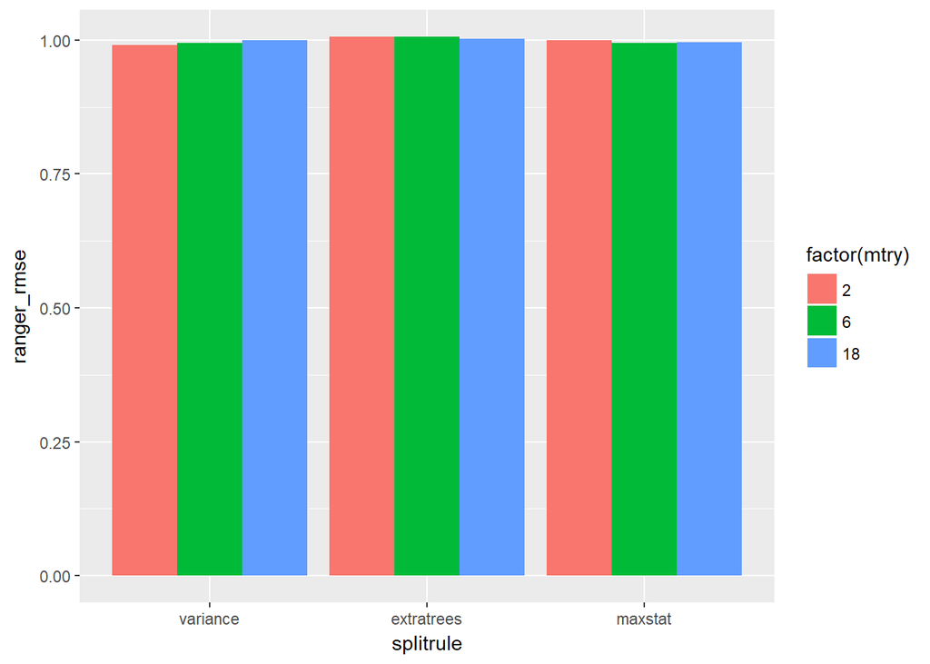

```r
candidate_params <- candidate_params %>%
  arrange(ranger_rmse)

best_mtry <- candidate_params$mtry[1]

best_splitrule <- candidate_params$splitrule[1]

candidate_params %>%
  ggplot(aes(splitrule, ranger_rmse, fill = factor(mtry))) +
  geom_col(position = "dodge")
```

```r
lm_foo <- function(split, ind_vars, my_recipe) {
  formula <- as.formula(paste0("landings ~ ", paste(ind_vars, collapse = "+")))

  prepped_recipe <- recipes::prep(my_recipe, training = rsample::analysis(split))

  analysis_data <- bake(prepped_recipe, newdata = rsample::analysis(split))

  assessment_data <- bake(prepped_recipe, newdata = rsample::assessment(split))

  fitted_lm <- lm(landings ~ ., data = analysis_data)

  lm_performance <- assessment_data %>%
  modelr::add_predictions(model = fitted_lm)

  metric <- yardstick::rmse(lm_performance, truth = landings, estimate = pred)
}

ranger_foo <- function(split, candidate_variables, dep_var, mtry, splitrule, my_recipe) {
  analysis_data <- rsample::analysis(split)

  prepped_recipe <- recipes::prep(my_recipe, training = analysis_data)

  analysis_data <- bake(prepped_recipe, newdata = analysis_data)

  assessment_data <- bake(prepped_recipe, newdata = rsample::assessment(split))

  fitted_forest <- ranger::ranger(landings ~ .,
                                  data = analysis_data,
                                  mtry = mtry,
                                  splitrule = splitrule)

  assessment_data$prediction = predict(fitted_forest, data = assessment_data)$predictions

  metric <- yardstick::rmse(assessment_data, truth = landings, estimate = prediction)
}

chile_vfold <- chile_vfold %>%
  mutate(lm_rmse = map_dbl(splits,
                           lm_foo,
                           ind_vars = candidate_variables,
                           my_recipe = chile_recipe),
         ranger_rmse = map_dbl(splits,
                               ranger_foo,
                               candidate_variables = candidate_variables,
                               mtry = best_mtry,
                               splitrule = best_splitrule,
                               my_recipe = chile_recipe))

chile_vfold
```

```
## #  5-fold cross-validation using stratification
## # A tibble: 5 x 4
##   splits       id    lm_rmse ranger_rmse
## * <list>       <chr>   <dbl>       <dbl>
## 1 <S3: rsplit> Fold1    1.08       0.960
## 2 <S3: rsplit> Fold2    1.09       0.985
## 3 <S3: rsplit> Fold3    2.10       1.03
## 4 <S3: rsplit> Fold4    1.04       0.997
## 5 <S3: rsplit> Fold5    1.03       0.980
```

```r
chile_performance <- chile_vfold %>%
  perf_mod(seed = 42)
```

[output not shown]

[output cut: 40 more lines]

[output not shown]

```r
forest_v_lm <- contrast_models(chile_performance, "ranger_rmse", "lm_rmse")

summary(forest_v_lm)
```

```
## # A tibble: 1 x 9
##   contrast    probability   mean  lower  upper  size pract_neg pract_equiv
##   <chr>             <dbl>  <dbl>  <dbl>  <dbl> <dbl>     <dbl>       <dbl>
## 1 ranger_rms~      0.0853 -0.266 -0.591 0.0589     0        NA          NA
## # ... with 1 more variable: pract_pos <dbl>
```

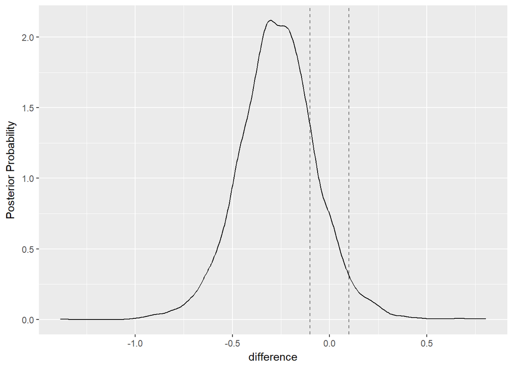

```r
ggplot(forest_v_lm, size = 0.1)
```

```r
chile_prepped <- prep(chile_recipe, training = chile_train)

fitted_forest <- ranger::ranger(
  landings ~ .,
  data =  bake(chile_prepped, newdata = chile_train),
  mtry = best_mtry,
  splitrule = best_splitrule,
  importance = "permutation")

fitted_lm <- lm(landings ~ ., data = bake(chile_prepped, newdata = chile_train))
```

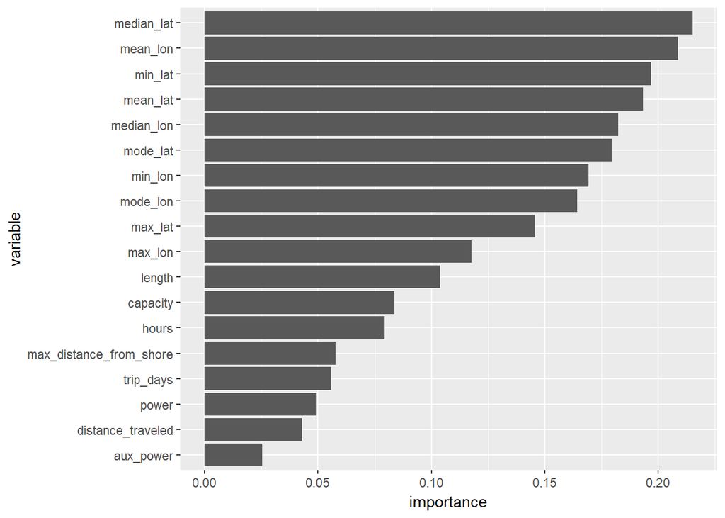

```r
data_frame(variable = names(ranger::importance(fitted_forest)),
           importance = ranger::importance(fitted_forest)) %>%
  mutate(variable = fct_reorder(variable, importance)) %>%
  ggplot(aes(variable, importance)) +
  geom_col() +
  coord_flip()
```

Compare fit on training data

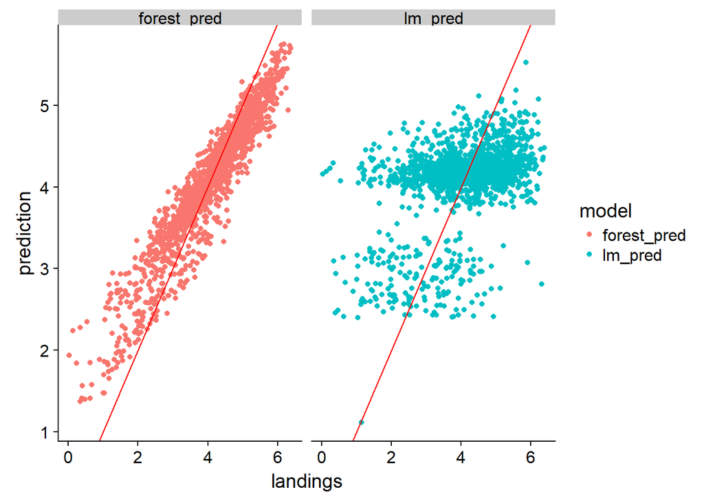

```r
chile_results <- bake(chile_prepped, newdata = chile_train) %>%
  mutate(lm_pred = predict(fitted_lm, newdata = bake(chile_prepped, newdata = chile_train)),
         forest_pred = predict(fitted_forest, data = bake(chile_prepped, newdata = chile_train))$predictions)


chile_results %>%
  select(landings, lm_pred, forest_pred) %>%
  gather(model, prediction, contains("pred")) %>%
  ggplot(aes(landings, prediction, color = model)) +
  geom_point() +
  geom_abline(aes(intercept = 0, slope = 1), color = "red") +
  facet_wrap( ~ model) +
  cowplot::theme_cowplot()
```

```r
cor(chile_results$landings, chile_results$forest_pred)^2
```

```
## [1] 0.9003417
```

```r
cor(chile_results$landings, chile_results$lm_pred)^2
```

```
## [1] 0.1852457
```

Compare fit on testing data

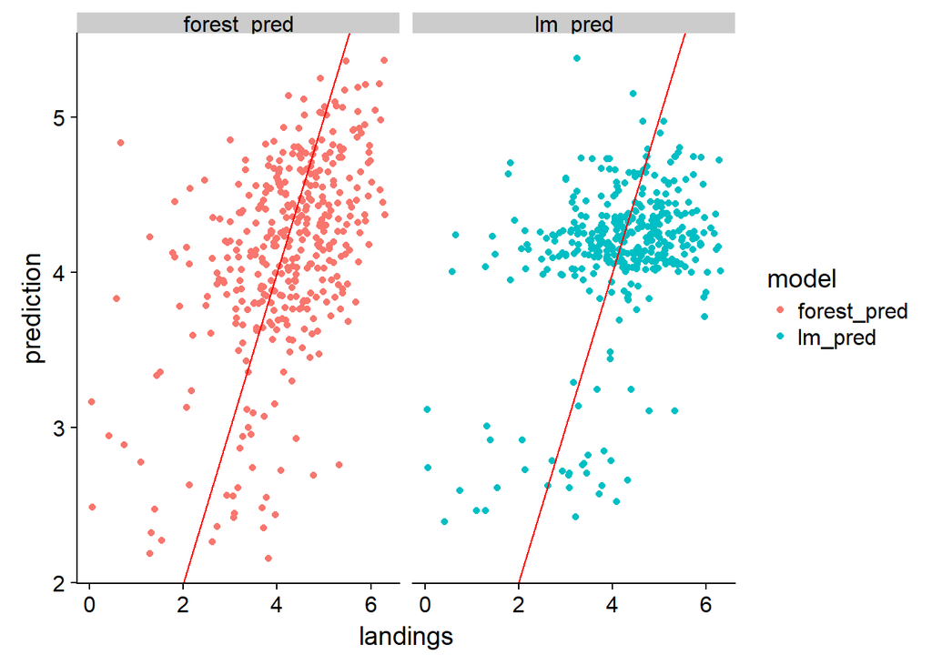

```r
chile_results <- bake(chile_prepped, newdata = chile_test) %>%
  mutate(lm_pred = predict(fitted_lm, newdata = bake(chile_prepped, newdata = chile_test)),
         forest_pred = predict(fitted_forest, data = bake(chile_prepped, newdata = chile_test))$predictions)


chile_results %>%
  select(landings, lm_pred, forest_pred) %>%
  gather(model, prediction, contains("pred")) %>%
  ggplot(aes(landings, prediction, color = model)) +
  geom_point() +
  geom_abline(aes(intercept = 0, slope = 1), color = "red") +
  facet_wrap( ~ model) +
  cowplot::theme_cowplot()
```

```r
cor(chile_results$landings, chile_results$forest_pred)^2
```

```
## [1] 0.2645965
```

```r
cor(chile_results$landings, chile_results$lm_pred)^2
```

```
## [1] 0.1588719
```

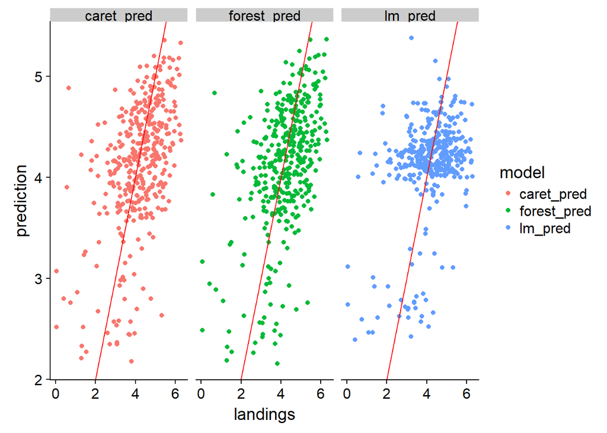

```r
fit_control <- trainControl(method = "repeatedcv",
                            number = 5,
                            repeats = 1,
                            allowParallel = TRUE)

caret_forest <- caret::train(chile_recipe,
                             data = chile_train,
                             method = "ranger",
                             trControl = fit_control)


chile_results <- chile_results %>%
  mutate(caret_pred = predict(caret_forest$finalModel,
                              data = select(chile_results, candidate_variables))$predictions)

chile_results %>%
  select(landings, lm_pred, forest_pred, caret_pred) %>%
  gather(model, prediction, contains("pred")) %>%
  ggplot(aes(landings, prediction, color = model)) +
  geom_point() +
  geom_abline(aes(intercept = 0, slope = 1), color = "red") +
  facet_wrap( ~ model) +
  cowplot::theme_cowplot()
```

```r
cor(chile_results$landings, chile_results$forest_pred)
```

```
## [1] 0.5143894
```

```r
cor(chile_results$landings, chile_results$lm_pred)
```

```
## [1] 0.3985874
```

```r
cor(chile_results$landings, chile_results$caret_pred)
```

```
## [1] 0.517918
```

# Next stepps

1 Improve model fit by adding SST + Chl-a + lagrangian structures? 2 Think of ways to include “areas” / “regions” other than min/max/mode/mean of Lat / Long 3 Include variance of the above 4 Apply a similar method to SSt + Chla + lagrangian 5 Use other algorithms 6 Two parts: - Using GFW to predict catches of in-sample boats - Can we use little data we have on this dataset to recreate timeseries of catches? (i.e. compare this to FAO data / SAU / official landings)